# R-Fundamentals Part 2 solutions

D-Lab

3/30/2019

# Part 2 solutions

## **Challenge 1**

1. Load the mammals “sleep_VIM” dataset from the data folder using `read.csv()`. Save it in a variable named “Sleep_VIM”.
2. Remember what `ls()` does? What does `dir()` do?

```r
# 1.
Sleep_VIM = read.csv("/Users/evan.admin/Desktop/R-Fundamentals/data-raw/sleep_VIM.csv",
                     header = T,
                     stringsAsFactors = T,
                     na.strings = NULL)

# 2.

# ls() will show you the variables saved in your global environment
ls()
```

```
## [1] "Sleep_VIM"
```

```r
# dir() will show you the files in your current working directory
dir()
```

```
## [1] "Part 1 solutions.Rmd"   "Part 2 solutions.Rmd"
## [3] "Part 3 solutions.Rmd"   "Part 4 solutions.Rmd"
## [5] "Part_1_solutions.html"  "Part_2_solutions_files"
## [7] "Part_2_solutions.Rmd"
```

## **Challenge 2**

1. Practice extracting a few variables from the `animals` dataframe using the dollar sign `$`
2. Plot them in a histogram using the `hist()` function. How do you do this?
3. Can all data types be visualized with histograms? Why or why not?

```r
load("/Users/evan.admin/Desktop/R-Fundamentals/data-proc/data.Rdata")
# 1.
gap$country
```

```
##    [1] Afghanistan              Afghanistan
##    [3] Afghanistan              Afghanistan
##    [5] Afghanistan              Afghanistan
##    [7] Afghanistan              Afghanistan
##    [9] Afghanistan              Afghanistan
##   [11] Afghanistan              Afghanistan
##   [13] Albania                  Albania
##   [15] Albania                  Albania
##   [17] Albania                  Albania
##   [19] Albania                  Albania
##   [21] Albania                  Albania
##   [23] Albania                  Albania
##   [25] Algeria                  Algeria
##   [27] Algeria                  Algeria
##   [29] Algeria                  Algeria
```

[output cut: 838 more lines]

```r
gap$continent
```

```
##    [1] Asia     Asia     Asia     Asia     Asia     Asia     Asia
##    [8] Asia     Asia     Asia     Asia     Asia     Europe   Europe
##   [15] Europe   Europe   Europe   Europe   Europe   Europe   Europe
##   [22] Europe   Europe   Europe   Africa   Africa   Africa   Africa
##   [29] Africa   Africa   Africa   Africa   Africa   Africa   Africa
##   [36] Africa   Africa   Africa   Africa   Africa   Africa   Africa
##   [43] Africa   Africa   Africa   Africa   Africa   Africa   Americas
##   [50] Americas Americas Americas Americas Americas Americas Americas
##   [57] Americas Americas Americas Americas Oceania  Oceania  Oceania
##   [64] Oceania  Oceania  Oceania  Oceania  Oceania  Oceania  Oceania
##   [71] Oceania  Oceania  Europe   Europe   Europe   Europe   Europe
##   [78] Europe   Europe   Europe   Europe   Europe   Europe   Europe
##   [85] Asia     Asia     Asia     Asia     Asia     Asia     Asia
##   [92] Asia     Asia     Asia     Asia     Asia     Asia     Asia
##   [99] Asia     Asia     Asia     Asia     Asia     Asia     Asia
```

[output cut: 230 more lines]

```r
gap$gdpPercap
```

```
##    [1]    779.4453    820.8530    853.1007    836.1971    739.9811
##    [6]    786.1134    978.0114    852.3959    649.3414    635.3414
##   [11]    726.7341    974.5803   1601.0561   1942.2842   2312.8890
##   [16]   2760.1969   3313.4222   3533.0039   3630.8807   3738.9327
##   [21]   2497.4379   3193.0546   4604.2117   5937.0295   2449.0082
##   [26]   3013.9760   2550.8169   3246.9918   4182.6638   4910.4168
##   [31]   5745.1602   5681.3585   5023.2166   4797.2951   5288.0404
##   [36]   6223.3675   3520.6103   3827.9405   4269.2767   5522.7764
##   [41]   5473.2880   3008.6474   2756.9537   2430.2083   2627.8457
##   [46]   2277.1409   2773.2873   4797.2313   5911.3151   6856.8562
##   [51]   7133.1660   8052.9530   9443.0385  10079.0267   8997.8974
##   [56]   9139.6714   9308.4187  10967.2820   8797.6407  12779.3796
##   [61]  10039.5956  10949.6496  12217.2269  14526.1246  16788.6295
##   [66]  18334.1975  19477.0093  21888.8890  23424.7668  26997.9366
##   [71]  30687.7547  34435.3674   6137.0765   8842.5980  10750.7211
```

[output cut: 326 more lines]

```r
# 2.
hist(gap$country) # Error in hist.default(gap$country) : 'x' must be numeric
```

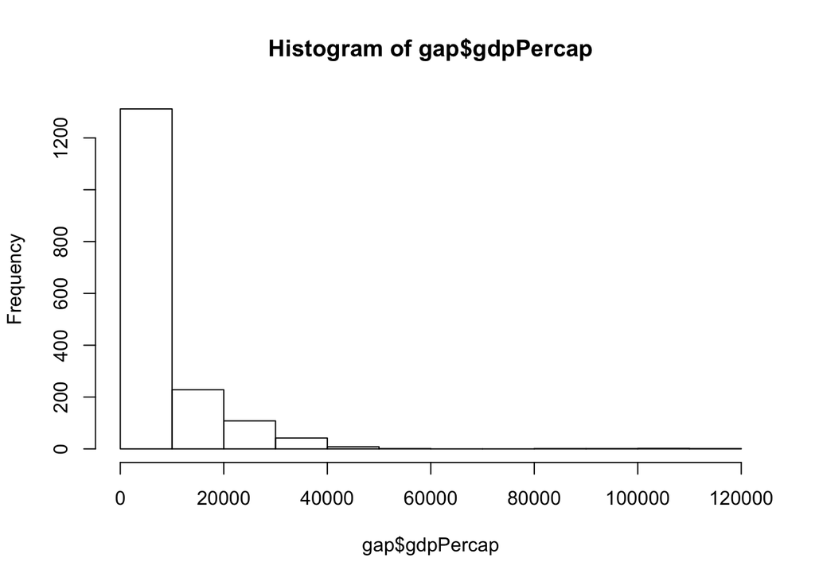

```r
hist(gap$gdpPercap)
```

```r
# 3. No, not all data types can be visualized with histograms. The error message above states that the input variable 'x' must be numeric!
```

## **Challenge 3**

1. Load the `iris` dataset! Type `data(iris)` to load it.
2. What is this dataset? How do you find out?
3. Subset the `iris` dataset in three ways using column names and positive and negative integers.
4. Subset `iris` using logical tests, `&`, and `|`

```r
# 1.
data(iris)

# 2.
?iris
str(iris)
```

```
## 'data.frame':    150 obs. of  5 variables:
##  $ Sepal.Length: num  5.1 4.9 4.7 4.6 5 5.4 4.6 5 4.4 4.9 ...
##  $ Sepal.Width : num  3.5 3 3.2 3.1 3.6 3.9 3.4 3.4 2.9 3.1 ...
##  $ Petal.Length: num  1.4 1.4 1.3 1.5 1.4 1.7 1.4 1.5 1.4 1.5 ...
##  $ Petal.Width : num  0.2 0.2 0.2 0.2 0.2 0.4 0.3 0.2 0.2 0.1 ...
##  $ Species     : Factor w/ 3 levels "setosa","versicolor",..: 1 1 1 1 1 1 1 1 1 1 ...
```

```r
# https://en.wikipedia.org/wiki/Iris_flower_data_set

# 3.
iris_varnames = iris[ , c("Sepal.Length", "Species")]
head(iris_varnames)
```

```
##   Sepal.Length Species
## 1          5.1  setosa
## 2          4.9  setosa
## 3          4.7  setosa
## 4          4.6  setosa
## 5          5.0  setosa
## 6          5.4  setosa
```

```r
iris_posint = iris[ , c(1, 5)]
head(iris_posint)
```

```
##   Sepal.Length Species
## 1          5.1  setosa
## 2          4.9  setosa
## 3          4.7  setosa
## 4          4.6  setosa
## 5          5.0  setosa
## 6          5.4  setosa
```

```r
iris_negint = iris[ , -c(2:4)]
head(iris_negint)
```

```
##   Sepal.Length Species
## 1          5.1  setosa
## 2          4.9  setosa
## 3          4.7  setosa
## 4          4.6  setosa
## 5          5.0  setosa
## 6          5.4  setosa
```

## **Challenge 4**

Subset `gap`:  
1. Once in one dimension.  
2. Twice in two dimensions using either bracket notation `[ , ]` or `subset`.  
3. Three times using logical tests.

```r
# 1.
gap$lifeExp
```

```
##    [1] 28.80100 30.33200 31.99700 34.02000 36.08800 38.43800 39.85400
##    [8] 40.82200 41.67400 41.76300 42.12900 43.82800 55.23000 59.28000
##   [15] 64.82000 66.22000 67.69000 68.93000 70.42000 72.00000 71.58100
##   [22] 72.95000 75.65100 76.42300 43.07700 45.68500 48.30300 51.40700
##   [29] 54.51800 58.01400 61.36800 65.79900 67.74400 69.15200 70.99400
##   [36] 72.30100 30.01500 31.99900 34.00000 35.98500 37.92800 39.48300
##   [43] 39.94200 39.90600 40.64700 40.96300 41.00300 42.73100 62.48500
##   [50] 64.39900 65.14200 65.63400 67.06500 68.48100 69.94200 70.77400
##   [57] 71.86800 73.27500 74.34000 75.32000 69.12000 70.33000 70.93000
##   [64] 71.10000 71.93000 73.49000 74.74000 76.32000 77.56000 78.83000
##   [71] 80.37000 81.23500 66.80000 67.48000 69.54000 70.14000 70.63000
##   [78] 72.17000 73.18000 74.94000 76.04000 77.51000 78.98000 79.82900
##   [85] 50.93900 53.83200 56.92300 59.92300 63.30000 65.59300 69.05200
##   [92] 70.75000 72.60100 73.92500 74.79500 75.63500 37.48400 39.34800
##   [99] 41.21600 43.45300 45.25200 46.92300 50.00900 52.81900 56.01800
```

[output cut: 229 more lines]

```r
# 2.
gap_bracket_notation = gap[c(1:3, 1704), 1:3]
gap_bracket_notation
```

```
##          country year      pop
## 1    Afghanistan 1952  8425333
## 2    Afghanistan 1957  9240934
## 3    Afghanistan 1962 10267083
## 1704    Zimbabwe 2007 12311143
```

```r
gap_subset_function = subset(gap,
                             subset = country == "Australia" | country == "New Zealand",
                             select = c(1,2,4))
gap_subset_function
```

```
##          country year continent
## 61     Australia 1952   Oceania
## 62     Australia 1957   Oceania
## 63     Australia 1962   Oceania
## 64     Australia 1967   Oceania
## 65     Australia 1972   Oceania
## 66     Australia 1977   Oceania
## 67     Australia 1982   Oceania
## 68     Australia 1987   Oceania
## 69     Australia 1992   Oceania
## 70     Australia 1997   Oceania
## 71     Australia 2002   Oceania
## 72     Australia 2007   Oceania
## 1093 New Zealand 1952   Oceania
## 1094 New Zealand 1957   Oceania
## 1095 New Zealand 1962   Oceania
## 1096 New Zealand 1967   Oceania
## 1097 New Zealand 1972   Oceania
## 1098 New Zealand 1977   Oceania
## 1099 New Zealand 1982   Oceania
## 1100 New Zealand 1987   Oceania
## 1101 New Zealand 1992   Oceania
## 1102 New Zealand 1997   Oceania
## 1103 New Zealand 2002   Oceania
## 1104 New Zealand 2007   Oceania
```

```r
# 3.
gap_logical1 = gap[gap$continent == "Oceania", ]
gap_logical1
```

```
##          country year      pop continent lifeExp gdpPercap
## 61     Australia 1952  8691212   Oceania  69.120  10039.60
## 62     Australia 1957  9712569   Oceania  70.330  10949.65
## 63     Australia 1962 10794968   Oceania  70.930  12217.23
## 64     Australia 1967 11872264   Oceania  71.100  14526.12
## 65     Australia 1972 13177000   Oceania  71.930  16788.63
## 66     Australia 1977 14074100   Oceania  73.490  18334.20
## 67     Australia 1982 15184200   Oceania  74.740  19477.01
## 68     Australia 1987 16257249   Oceania  76.320  21888.89
## 69     Australia 1992 17481977   Oceania  77.560  23424.77
## 70     Australia 1997 18565243   Oceania  78.830  26997.94
## 71     Australia 2002 19546792   Oceania  80.370  30687.75
## 72     Australia 2007 20434176   Oceania  81.235  34435.37
## 1093 New Zealand 1952  1994794   Oceania  69.390  10556.58
## 1094 New Zealand 1957  2229407   Oceania  70.260  12247.40
## 1095 New Zealand 1962  2488550   Oceania  71.240  13175.68
## 1096 New Zealand 1967  2728150   Oceania  71.520  14463.92
## 1097 New Zealand 1972  2929100   Oceania  71.890  16046.04
## 1098 New Zealand 1977  3164900   Oceania  72.220  16233.72
## 1099 New Zealand 1982  3210650   Oceania  73.840  17632.41
## 1100 New Zealand 1987  3317166   Oceania  74.320  19007.19
## 1101 New Zealand 1992  3437674   Oceania  76.330  18363.32
## 1102 New Zealand 1997  3676187   Oceania  77.550  21050.41
## 1103 New Zealand 2002  3908037   Oceania  79.110  23189.80
## 1104 New Zealand 2007  4115771   Oceania  80.204  25185.01
```

```r
gap_logical2 = gap[gap$country == "Mexico" & gap$year == 2007, ]
gap_logical2
```

```
##     country year       pop continent lifeExp gdpPercap
## 996  Mexico 2007 108700891  Americas  76.195  11977.57
```

```r
gap_logical3 = gap[gap$country == "Mexico" | gap$year == 2007, ]
gap_logical3
```

```
##                       country year        pop continent lifeExp  gdpPercap
## 12                Afghanistan 2007   31889923      Asia  43.828   974.5803
## 24                    Albania 2007    3600523    Europe  76.423  5937.0295
## 36                    Algeria 2007   33333216    Africa  72.301  6223.3675
## 48                     Angola 2007   12420476    Africa  42.731  4797.2313
## 60                  Argentina 2007   40301927  Americas  75.320 12779.3796
## 72                  Australia 2007   20434176   Oceania  81.235 34435.3674
## 84                    Austria 2007    8199783    Europe  79.829 36126.4927
## 96                    Bahrain 2007     708573      Asia  75.635 29796.0483
## 108                Bangladesh 2007  150448339      Asia  64.062  1391.2538
## 120                   Belgium 2007   10392226    Europe  79.441 33692.6051
## 132                     Benin 2007    8078314    Africa  56.728  1441.2849
## 144                   Bolivia 2007    9119152  Americas  65.554  3822.1371
## 156    Bosnia and Herzegovina 2007    4552198    Europe  74.852  7446.2988
## 168                  Botswana 2007    1639131    Africa  50.728 12569.8518
```

[output cut: 139 more lines]

## **Challenge 5**

# Do the number of missing cases in s_NA equal that to the whole data set?

```r
sum(is.na(s_NA)) == sum(is.na(sleep_VIM))
# ... yes! Both data objects contain 38 NA values!
```

[output not shown]

## **Challenge6**

1. Subsetting review. Use `gap` to create a subsetted dataframe named `UnitedStates_Mexico` that contains only data for countries USA and Mexico. (hint: does “and” actually mean “and” here?)
2. Create a subsetted data frame that only contains only the country USA and lifeExp greater than 76. Save this in a variable named `US_lifeExp`. (hint: what is the meaning of “and” here in contrast to question #1?)

```r
# 1. Here, "and" actually means we need to use the "or" | operator to select data for either United States or Mexico.
UnitedStates_Mexico = gap[gap$country == "United States" | gap$country == "Mexico", ]
UnitedStates_Mexico
```

```
##            country year       pop continent lifeExp gdpPercap
## 985         Mexico 1952  30144317  Americas  50.789  3478.126
## 986         Mexico 1957  35015548  Americas  55.190  4131.547
## 987         Mexico 1962  41121485  Americas  58.299  4581.609
## 988         Mexico 1967  47995559  Americas  60.110  5754.734
## 989         Mexico 1972  55984294  Americas  62.361  6809.407
## 990         Mexico 1977  63759976  Americas  65.032  7674.929
## 991         Mexico 1982  71640904  Americas  67.405  9611.148
## 992         Mexico 1987  80122492  Americas  69.498  8688.156
## 993         Mexico 1992  88111030  Americas  71.455  9472.384
## 994         Mexico 1997  95895146  Americas  73.670  9767.298
## 995         Mexico 2002 102479927  Americas  74.902 10742.441
## 996         Mexico 2007 108700891  Americas  76.195 11977.575
## 1609 United States 1952 157553000  Americas  68.440 13990.482
## 1610 United States 1957 171984000  Americas  69.490 14847.127
## 1611 United States 1962 186538000  Americas  70.210 16173.146
## 1612 United States 1967 198712000  Americas  70.760 19530.366
## 1613 United States 1972 209896000  Americas  71.340 21806.036
## 1614 United States 1977 220239000  Americas  73.380 24072.632
## 1615 United States 1982 232187835  Americas  74.650 25009.559
## 1616 United States 1987 242803533  Americas  75.020 29884.350
## 1617 United States 1992 256894189  Americas  76.090 32003.932
## 1618 United States 1997 272911760  Americas  76.810 35767.433
## 1619 United States 2002 287675526  Americas  77.310 39097.100
## 1620 United States 2007 301139947  Americas  78.242 42951.653
```

```r
# 2. Here, we must use the "and" & operator so that both conditions (United States, lifeExp > 76) are satisfied.
US_lifeExp = gap[gap$country == "United States" & gap$lifeExp > 76, ]
US_lifeExp
```

```
##            country year       pop continent lifeExp gdpPercap
## 1617 United States 1992 256894189  Americas  76.090  32003.93
## 1618 United States 1997 272911760  Americas  76.810  35767.43
## 1619 United States 2002 287675526  Americas  77.310  39097.10
## 1620 United States 2007 301139947  Americas  78.242  42951.65
```